# ggplot2 examples

nik@nikhouri.com

# Formatting Guide

## Categorical Data & Discrete Colours

Categorical legends are best put at the top of the plot. Readers first see what categories are displayed, *then* how they relate to each other. Colour scales should be colourblind-safe. Here are some colourblind-safe palettes. The default R ones are not.

- [Paul Tol’s palletes](https://personal.sron.nl/~pault/#sec:qualitative) - the *vibrant* colour set are good for line charts, *bright* are OK for bars. Lots of other colourblind-safe choices.
- [Okabe & Ito](https://jfly.uni-koeln.de/color/) - looks good on bars, but a couple of colours are too light for line charts.
- [ColorBrewer 2.0](https://colorbrewer2.org/) - is also good but doesn’t have as many colours in the qualitative sets.

```r
tolvibrant <- c("#0077BB", "#33BBEE", "#009988", "#EE7733", "#CC3311", "#EE3377", "#BBBBBB")
tolbright <- c("#4477AA", "#66CCEE", "#228833", "#CCBB44", "#EE6677", "#AA3377", "#BBBBBB")
okabe <- c("#E69F00", "#56B4E9", "#009E73", "#F0E442", "#0072B2", "#D55E00", "#CC79A7")
```

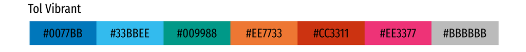

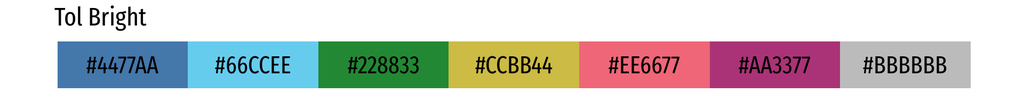

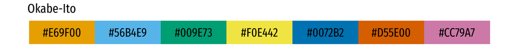

Okabe & Ito also have good advice on figures:

1. Make lines thicker, symbols larger
2. Use various types of lines and symbols
3. Avoid separate keys. Add labels within drawings.

Other formatting resources:

- [The Economist’s charts & maps style guides](https://design-system.economist.com/brand-and-marketing)
- [The Financial Times’ Chart Doctor series](https://www.ft.com/chart-doctor)

## Continuous Data & Colours

Continuous data legends are best put at the bottom of the plot. Readers first see the shape of the data, *then* can look up specific values via the legend. Colour scales should be colourblind-safe. [viridis](https://cran.r-project.org/web/packages/viridis/vignettes/intro-to-viridis.html), is colourblind-safe and built in to ggplot2 now anyway. There are alternative viridis sets - but these need the library.

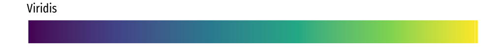

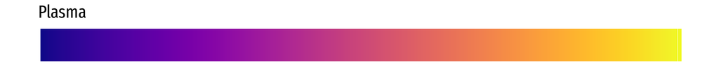

```r
# Builtin to ggplot
ggplot() + scale_fill_continuous(type="viridis")

# Not builtin to ggplot - needs the viridis library
library(viridis)
ggplot() + scale_fill_viridis(option="plasma")
```

## Fonts

These are good condensed fonts. It allows you to squeeze in more text without having to abbreviate things in the title (and also looks good).

- Fira Sans Extra Condensed - these examples use this font.
- IBM Plex Sans Condensed - good alternative choice if using that family.

…except for small numeric labels inline on the charts (ex. point-and-figure below). Defaults are better there.

```r
family="Fira Sans Extra Condensed" # General
family="Fira Sans Extra Condensed Medium" # Titles
```

## Number Formatting

Common formatting changes for axes.

```r
# Add thousands separators (spaces)
numfmt <- function(x) format(x, big.mark=" ", decimal.mark=".", scientific=FALSE)
# Abbreviated numbers (thousands, millions, billions, trillions)
bignumfmt <- function(x) {
    if (x < 10**6) paste0(format(round(x/1000,0),big.mark=" ",decimal.mark="."),"K")
    else if (x < 10**9) paste0(format(round(x/10**6,1),big.mark=" ", decimal.mark="."),"M")
    else if (x < 10**12) paste0(format(round(x/10**9,1),big.mark=" ",decimal.mark=".",),"B")
    else paste0(format(round(x/10**12,1),big.mark=" ",decimal.mark=".",),"T")
}
```

# Statistic Charts

## Scatter: `geom_point()`

Example using CPU vs. CPU temperature, with a line overlay.

- Categories shown using shape and colour (and larger size)
- Legend moved to top (categories visible first, then data)
- Fit lines using a linear model (default is `loess` — example, not a real analysis!)

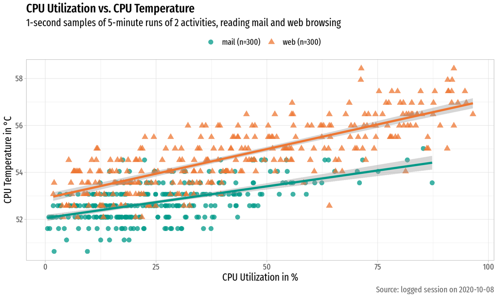

```r
library(ggplot2)

# Read in data file to data frame
df <- read.csv('data/rpicpu.csv', sep=';',
               colClasses=c('factor','POSIXct','numeric','numeric'))

# Add counts to legend labels
df$label <- paste0(df$label," (n=",table(df$label)[df$label],")")

# Tol Bright extract
tolmini <- c("#009988","#EE7733")

# Plot data
ggplot(df) +
    # Data series
    geom_point(aes(x=cpu, y=temp, color=label, shape=label), alpha=0.75, size=3) +
    geom_smooth(aes(x=cpu, y=temp, color=label), method=lm, formula=y ~ x,
                size=1.5, show.legend=FALSE) +
    # Axis scales and colour scales
    scale_color_discrete(type=tolmini) +
    # Plot labels
    labs(x="CPU Utilization in %",y="CPU Temperature in °C", color=NULL, shape=NULL,
         title="CPU Utilization vs. CPU Temperature",
         subtitle="1-second samples of 5-minute runs of 2 activities, reading mail and web browsing",
         caption="Source: logged session on 2020-10-08") +
    # Themeing & fonts
    theme_light() +
    theme(legend.position="top",
          text=element_text(size=15, family="Fira Sans Extra Condensed"),
          plot.title=element_text(family="Fira Sans Extra Condensed Medium"),
          plot.caption=element_text(color="#666666"))
```

## Histogram `geom_histogram()` and `stat_ecdf()`

Histograms of the CPU data. Secondary axes are not easy to do in ggplot2, this example uses a manual factor to adjust thsse scaling.

- Categorised & fill/line colour varies by group
- Cumulative distribution shown for each category, on second axis (scaled by manually chosen factor)

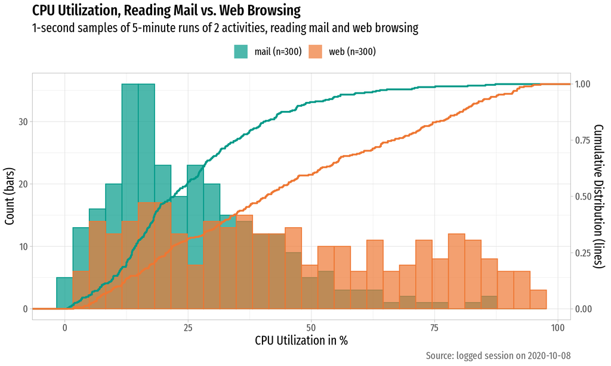

```r
library(ggplot2)

# Read in data file to data frame
df <- read.csv('data/rpicpu.csv', sep=';',
               colClasses=c('factor','POSIXct','numeric','numeric'))

# Add counts to legend labels
df$label <- paste0(df$label," (n=",table(df$label)[df$label],")")

# Tol Bright extract
tolmini <- c("#009988","#EE7733")

# Scale factor for secondary axis. Plot the chart, look for the max bar
# value on the histogram, try magics around that number until it looks good
magic <- 36

# Plot data
ggplot(df) +
    # Data series
    geom_histogram(aes(x=cpu, fill=label, color=label), bins=30,
                   position="identity", alpha=0.7) +
    stat_ecdf(aes(x=cpu, y=..y.. * magic, color=label), geom="step", size=1) +
    # Axis scales and colour scales
    scale_y_continuous(sec.axis=sec_axis(~ . / magic, name="Cumulative Distribution (lines)")) +
    scale_fill_discrete(type=tolmini) +
    scale_color_discrete(type=tolmini) +
    # Plot labels
    labs(x="CPU Utilization in %",y="Count (bars)", fill=NULL, color=NULL,
         title="CPU Utilization, Reading Mail vs. Web Browsing",
         subtitle="1-second samples of 5-minute runs of 2 activities, reading mail and web browsing",
         caption="Source: logged session on 2020-10-08") +
    guides(color="none",fill="legend") +
    # Themeing & fonts
    theme_light() +
    theme(legend.position="top",
          text=element_text(size=15, family="Fira Sans Extra Condensed"),
          plot.title=element_text(family="Fira Sans Extra Condensed Medium"),
          plot.caption=element_text(color="#666666"))
```

## Boxplot `geom_boxplot()` and `geom_jitter()`

Boxplots of the CPU data.

- One boxplot per category
- Underlying data shown as jittered points (coloured by category), see also https://simplystatistics.org/2019/02/21/dynamite-plots-must-die/

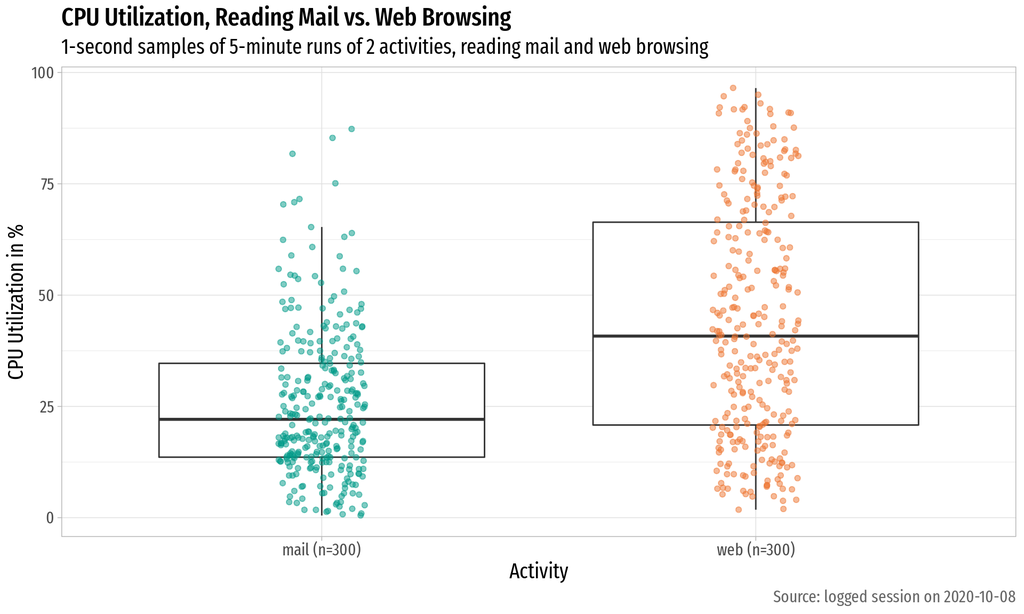

```r
library(ggplot2)

# Read in data file to data frame
df <- read.csv('data/rpicpu.csv', sep=';',
               colClasses=c('factor','POSIXct','numeric','numeric'))

# Add counts to legend labels
df$label <- paste0(df$label," (n=",table(df$label)[df$label],")")

# Tol Bright extract
tolmini <- c("#009988","#EE7733")

# Plot data
ggplot(df) +
    # Data series
    geom_boxplot(aes(x=label, y=cpu), outlier.shape=NA) +
    geom_jitter(aes(x=label, y=cpu, color=label), width=0.1, alpha=0.5) +
    # Axis scales and colour scales
    scale_fill_discrete(type=tolmini) +
    scale_color_discrete(type=tolmini) +
    # Plot labels
    labs(x="Activity",y="CPU Utilization in %", fill=NULL, color=NULL,
         title="CPU Utilization, Reading Mail vs. Web Browsing",
         subtitle="1-second samples of 5-minute runs of 2 activities, reading mail and web browsing",
         caption="Source: logged session on 2020-10-08") +
    # Themeing & fonts
    theme_light() +
    theme(legend.position="hidden",
          text=element_text(size=15, family="Fira Sans Extra Condensed"),
          plot.title=element_text(family="Fira Sans Extra Condensed Medium"),
          plot.caption=element_text(color="#666666"))
```

# Basic Charts

## Lines (time series): `geom_line()`

Oil production data from BP (via Quandl).

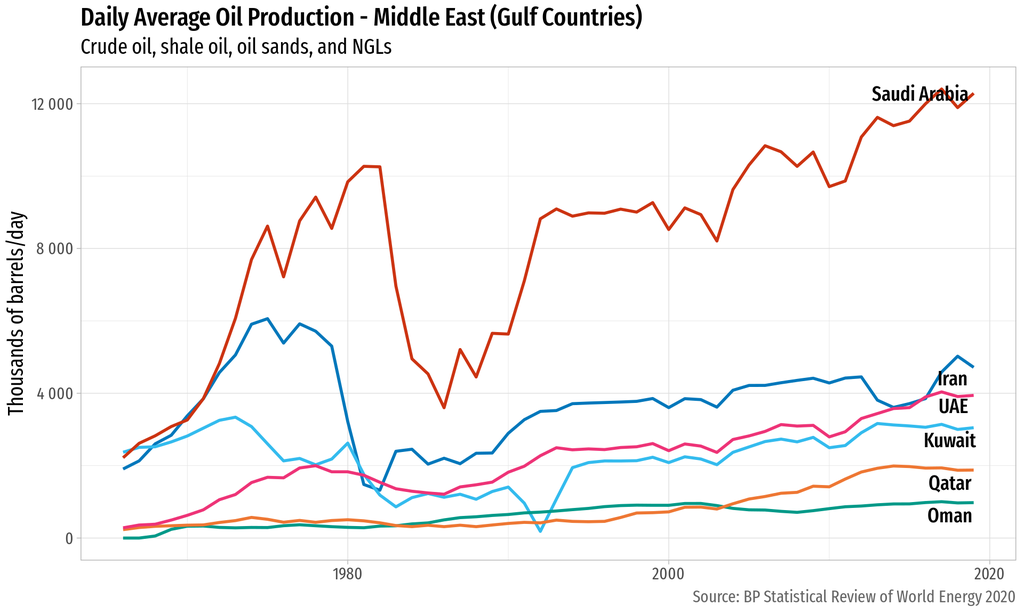

```r
library(ggplot2)
library(ggrepel)

# Read in data file to data frame
df <- read.csv('data/oildata.csv', sep=';',
               colClasses=c("Date","numeric","factor"))

# Label data
labels <- merge(aggregate(Value ~ Country, data=df, FUN=head, n=1), df)

# Tol Vibrant colour map
tolvibrant <- c("#0077BB", "#33BBEE", "#009988", "#EE7733", "#CC3311", "#EE3377", "#BBBBBB")

# Number format function
numfmt <- function(x) format(x, big.mark=" ", decimal.mark=".", scientific=FALSE)

# Plot data
ggplot(df) +
    # Data series
    geom_line(aes(x=Date,y=Value,color=Country), size=1) +
    # Data labels
    geom_text_repel(data=labels, aes(x=Date,y=Value,label=Country),
                    size=5, seed=9, family="Fira Sans Extra Condensed Medium") +
    # Axis scales and colour scales
    scale_y_continuous(label=numfmt) +
    scale_color_discrete(type=tolvibrant) +
    # Plot labels
    labs(title="Daily Average Oil Production - Middle East (Gulf Countries)",
         x=NULL, y="Thousands of barrels/day",
         subtitle = "Crude oil, shale oil, oil sands, and NGLs",
         caption="Source: BP Statistical Review of World Energy 2020") +
    # Themeing & fonts
    theme_light() +
    theme(legend.position="hidden",
          text=element_text(size=15, family="Fira Sans Extra Condensed"),
          plot.title=element_text(family="Fira Sans Extra Condensed Medium"),
          plot.caption=element_text(color="#666666"))
```

## Stepped Line (time series): `geom_step()`

Useful for granular price data (tick data), where you have all the exact values and interpolation isn’t appropriate.

Bank of England interest rate data https://www.bankofengland.co.uk/monetary-policy/the-interest-rate-bank-rate

- Factors sorted to order they appear in the data
- y-axis scale given explicit break widths
- Steps with colours/factor changes need dummy rows added with duplicate data to keep the line continuous (if that’s what you want)

Actual data:

```
2005-08-04;4.5;Repo Rate
2006-08-03;4.75;Official Bank Rate
```

Data with dummy row:

```
2005-08-04;4.5;Repo Rate
2006-08-03;4.75;Repo Rate
2006-08-03;4.75;Official Bank Rate
```

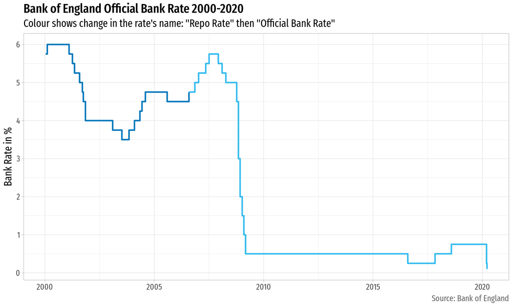

```r
library(ggplot2)

# Read in the data file to data frame
df <- read.csv('data/ukbankrate.csv', sep=';',
               colClasses=c("Date","numeric","factor"))

# Sort factor so it maintains order it appears in the data (for the legend)
df$Type <- factor(df$Type, levels=unique(df$Type), ordered=TRUE)

# Tol Vibrant colour map
tolvibrant <- c("#0077BB", "#33BBEE", "#009988", "#EE7733", "#CC3311", "#EE3377", "#BBBBBB")

# Plot data
ggplot(df) +
# Data series
    geom_step(aes(x=Date,y=Rate,color=Type), size=1) +
    # Axis scales and colour scales
    scale_y_continuous(breaks=scales::breaks_width(1)) +
    scale_color_discrete(type=tolvibrant) +
    # Plot labels
    labs(title="Bank of England Official Bank Rate 2000-2020",
         x=NULL, y="Bank Rate in %", color=NULL,
         subtitle = 'Colour shows change in the rate\'s name: "Repo Rate" then "Official Bank Rate"',
         caption="Source: Bank of England") +
    # Themeing & fonts
    theme_light() +
    theme(legend.position="hidden",strip.background=element_blank(),
          text=element_text(size=15, family="Fira Sans Extra Condensed"),
          plot.title=element_text(family="Fira Sans Extra Condensed Medium"),
          plot.caption=element_text(color="#666666"))
```

## Bars: `geom_col()`

Oil data aggregated into a total by year.

- `geom_col()` shows underlying values (by default)
- `geom_bar()` performs a count (by default)

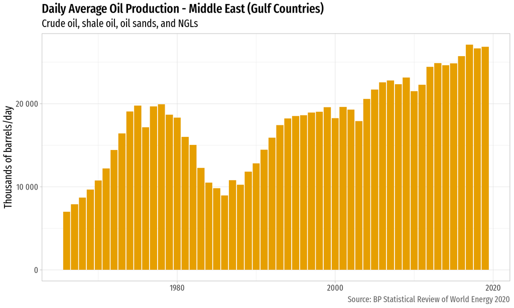

```r
library(ggplot2)

# Read in data file to data frame, and total it
df <- read.csv('data/oildata.csv', sep=';',
               colClasses=c("Date","numeric","factor"))
totals <- aggregate(Value~Date,data=df,FUN=sum)

# Okabe Ito colour map
okabe <- c("#E69F00", "#56B4E9", "#009E73", "#F0E442", "#0072B2", "#D55E00", "#CC79A7")

# Number format function
numfmt <- function(x) format(x, big.mark=" ", decimal.mark=".", scientific=FALSE)

# Plot data
ggplot(totals) +
    # Data series
    geom_col(aes(x=Date, y=Value), fill=okabe[1]) +
    # Axis scales and colour scales
    scale_y_continuous(label=numfmt) +
    # Plot labels
    labs(title="Daily Average Oil Production - Middle East (Gulf Countries)",
         x=NULL, y="Thousands of barrels/day",
         subtitle="Crude oil, shale oil, oil sands, and NGLs",
         caption="Source: BP Statistical Review of World Energy 2020",
         fill=NULL) +
    # Themeing & fonts
    theme_light() +
    theme(legend.position="top",
          text=element_text(size=15, family="Fira Sans Extra Condensed"),
          plot.title=element_text(family="Fira Sans Extra Condensed Medium"),
          plot.caption=element_text(color="#666666"))
```

## Stacked Bars: `geom_bar()`

Oil data presented as a stacked bar chart instead.

- Data sorted largest at the bottom to smallest at the top
- Legend moved to top (categories visible first, then data)

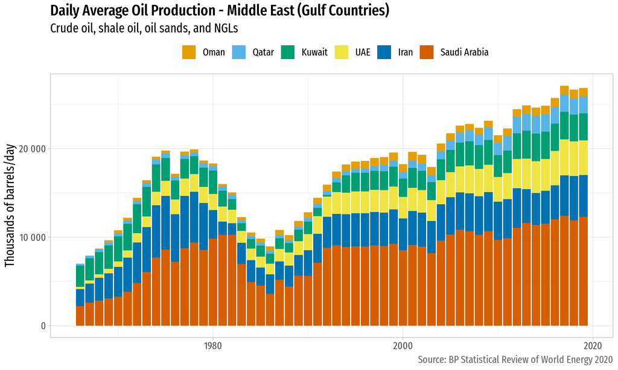

```r
library(ggplot2)

# Read in data file to data frame, get latest year
df <- read.csv('data/oildata.csv', sep=';',
               colClasses=c("Date","numeric","factor"))

# Re-order so largest values sink to bottom
df_ord <- df[df$Date == max(df$Date),]
df$Country <- factor(df$Country,
                     levels=df_ord$Country[order(df_ord$Value, decreasing=FALSE)])

# Okabe Ito colour map
okabe <- c("#E69F00", "#56B4E9", "#009E73", "#F0E442", "#0072B2", "#D55E00", "#CC79A7")

# Number format function
numfmt <- function(x) format(x, big.mark=" ", decimal.mark=".", scientific=FALSE)

# Plot data
ggplot(df) +
    # Data series
    geom_bar(aes(fill=Country, x=Date, y=Value), position="stack", stat="identity") +
    # Axis scales and colour scales
    scale_y_continuous(label=numfmt) +
    scale_fill_discrete(type=okabe,
                        guide=guide_legend(nrow=1)) +
    # Plot labels
    labs(title="Daily Average Oil Production - Middle East (Gulf Countries)",
         x=NULL, y="Thousands of barrels/day",
         subtitle="Crude oil, shale oil, oil sands, and NGLs",
         caption="Source: BP Statistical Review of World Energy 2020",
         fill=NULL) +
    # Themeing & fonts
    theme_light() +
    theme(legend.position="top",
          text=element_text(size=15, family="Fira Sans Extra Condensed"),
          plot.title=element_text(family="Fira Sans Extra Condensed Medium"),
          plot.caption=element_text(color="#666666"))
```

## Column (horizontal bars): `geom_col() + coord_flip()`

Better than vertical bars when the categories have longer names–they don’t all get squished up. Also a good way of showing percentage data instead of a pie chart.

Allergy test results

- Column (horizontal bar, using `coord_flip()`) plot, sorted by re-factoring
- Categorised by adding a dummy variable & fill colour varies by group
- In-chart annotation on threshold range - replaces legend
- Data labels at the end of bars

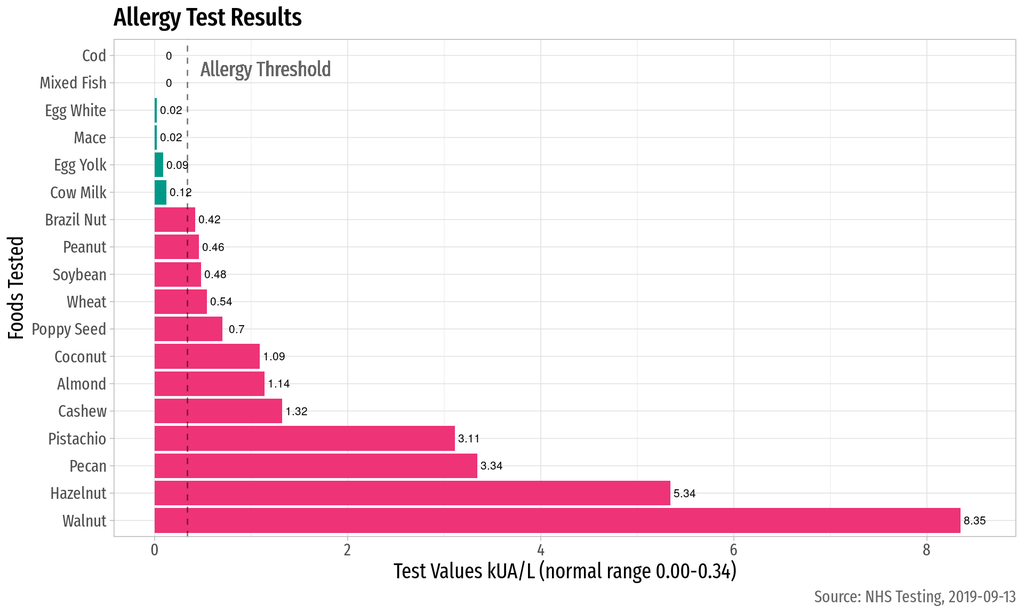

```r
library(ggplot2)

# Read in data file to data frame
df <- read.csv('data/allergytest.csv', sep=';')

# Create groups for colouring & re-order data frame by test values (ascending)
df$over_range = df$test_values < 0.34
df$foods <- factor(df$foods,
                   levels=df$food[order(df$test_values, decreasing=TRUE)])

# Tol Vibrant extract
tolmini <- c("#EE3377","#009988")

# Plot data
ggplot(df) +
    # Data series
    geom_col(aes(foods, test_values, fill=over_range)) +
    # Data labels
    geom_text(aes(x=foods, y=test_values, label=test_values),
              nudge_y=0.15, color="black", size=2.75) +
    # Threshold line
    geom_hline(yintercept=0.34, linetype="dashed", color="black", alpha=0.5) +
    geom_text(aes(nrow(df)-0.5,0.34,label="Allergy Threshold",hjust=-0.1),
              family="Fira Sans Extra Condensed", size=5, color="grey40") +
    # Axis scales and colour scales
    scale_fill_discrete(type=tolmini) +
    coord_flip() +
    # Plot labels
    labs(x="Foods Tested",y="Test Values kUA/L (normal range 0.00-0.34)",
         title="Allergy Test Results",
         caption="Source: NHS Testing, 2019-09-13") +
    # Themeing & fonts
    theme_light() +
    theme(legend.position="hidden",
          text=element_text(size=15, family="Fira Sans Extra Condensed"),
          plot.title=element_text(family="Fira Sans Extra Condensed Medium"),
          plot.caption=element_text(color="#666666"))
```

## Point and Range: `geom_pointrange()`

Allergy test results presented as point and range instead.

- Data sorted
- Categorised by adding dummy variable & colour varies by group
- Range displays normal value range - replaces legend
- Data labels on top of and slightly offset from points

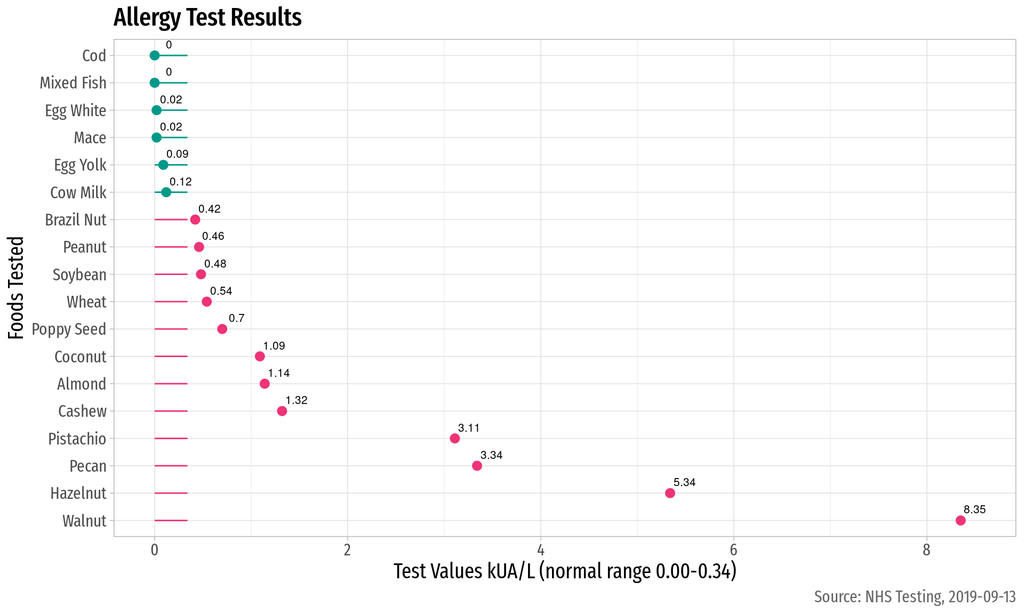

```r
library(ggplot2)

# Read in data file to data frame
df <- read.csv('data/allergytest.csv', sep=';')

# Create groups for colouring & re-order data frame by test values (ascending)
df$over_range = df$test_values < 0.34
df$foods <- factor(df$foods,
                   levels=df$food[order(df$test_values, decreasing=TRUE)])

# Tol Vibrant extract
tolmini <- c("#EE3377","#009988")

# Plot data
ggplot(df) +
    # Data series
    geom_pointrange(aes(x=foods, y=test_values, ymin=range_lo, ymax=range_hi,
                        color=over_range)) +
    # Data labels
    geom_text(aes(x=foods, y=test_values, label=test_values), nudge_y=0.15,
              nudge_x=0.4, color="black", size=2.75) +
    # Axis scales and colour scales
    scale_color_discrete(type=tolmini) +
    coord_flip() +
    # Plot labels
    labs(x="Foods Tested",y="Test Values kUA/L (normal range 0.00-0.34)",
         title="Allergy Test Results",
         caption="Source: NHS Testing, 2019-09-13") +
    # Themeing & fonts
    theme_light() +
    theme(legend.position="hidden",
          text=element_text(size=15, family="Fira Sans Extra Condensed"),
          plot.title=element_text(family="Fira Sans Extra Condensed Medium"),
          plot.caption=element_text(color="#666666"))
```

# Complex Charts

## Facets: `facet_wrap()`

Apple COVID‑19 Mobility Trends Reports. No points for guessing when the music festival is.

- Read data directly from a compressed file
- De-pivot data
- Facets with custom themeing
- Shaded regions

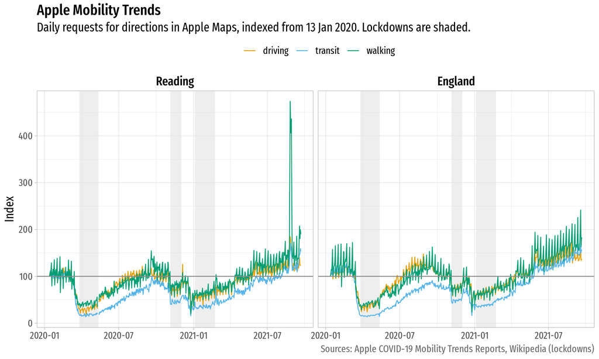

```r
library(tidyr)
library(ggplot2)

# Import & un-pivot data. read.csv can take compressed files directly!
amob <- read.csv('data/applemobilitytrends-2021-09-21.csv.bz2')
gamob <- gather(amob, "date", "index", 7:ncol(amob))
gamob$pdate <- as.Date(gamob$date,format="X%Y.%m.%d")

# Extract our regions. NB: regions which are countries have $country blank
regions <- c('Reading', 'England')
rdata <- gamob[gamob$region %in% regions & gamob$country=='United Kingdom',]
rdata$region <- factor(rdata$region, levels=regions, ordered=TRUE) # Re-order

lockdowns <- data.frame(start=as.Date(c('2020-03-26','2020-11-05','2021-01-04')),
                        end=as.Date(c('2020-05-13','2020-12-02','2021-02-22')))

# Okabe-Ito colour map
okabe <- c("#E69F00", "#56B4E9", "#009E73", "#F0E442", "#0072B2", "#D55E00", "#CC79A7")

# Number format function
numfmt <- function(x) format(x, big.mark=" ", decimal.mark=".", scientific=FALSE)

ggplot(rdata) +
  # Lockdown ranges
  geom_rect(data=lockdowns,aes(xmin=start,xmax=end,ymin=-Inf,ymax=Inf),
            alpha=0.5,fill=c('#DDDDDD')) +
  # Time series
    geom_line(aes(x=pdate,y=index,color=transportation_type)) +
  # Baseline
    geom_hline(yintercept=100, color="#888888") +
    # Axis scales and colour scales
    scale_y_continuous(label=numfmt) +
    scale_color_discrete(type=okabe) +
    facet_wrap(vars(region),ncol=4) +
    # Plot labels
    labs(title="Apple Mobility Trends",
         x=NULL, y="Index",
         subtitle = "Daily requests for directions in Apple Maps, indexed from 13 Jan 2020. Lockdowns are shaded.",
         caption="Sources: Apple COVID‑19 Mobility Trends Reports, Wikipedia (lockdowns)",
         color=NULL) +
    # Themeing & fonts
    theme_light() +
    theme(legend.position="top",
          text=element_text(size=15, family="Fira Sans Extra Condensed"),
          plot.title=element_text(family="Fira Sans Extra Condensed Medium"),
          plot.caption=element_text(color="#666666"),
          strip.background=element_blank(),
          strip.text=element_text(size=15, color="black",
            family="Fira Sans Extra Condensed Medium"))
```

## Multi-panel charts `gridExtra()`

Combine 2 different views of the data, using stacked bars (showing individual series combining to a total) and line charts (showing detail on individual series). Oil data.

- Same underlying data, 2 different presentations
- `gridExtra::grid.arrange()` is simple to use and works with ggplot (`par()` does not).

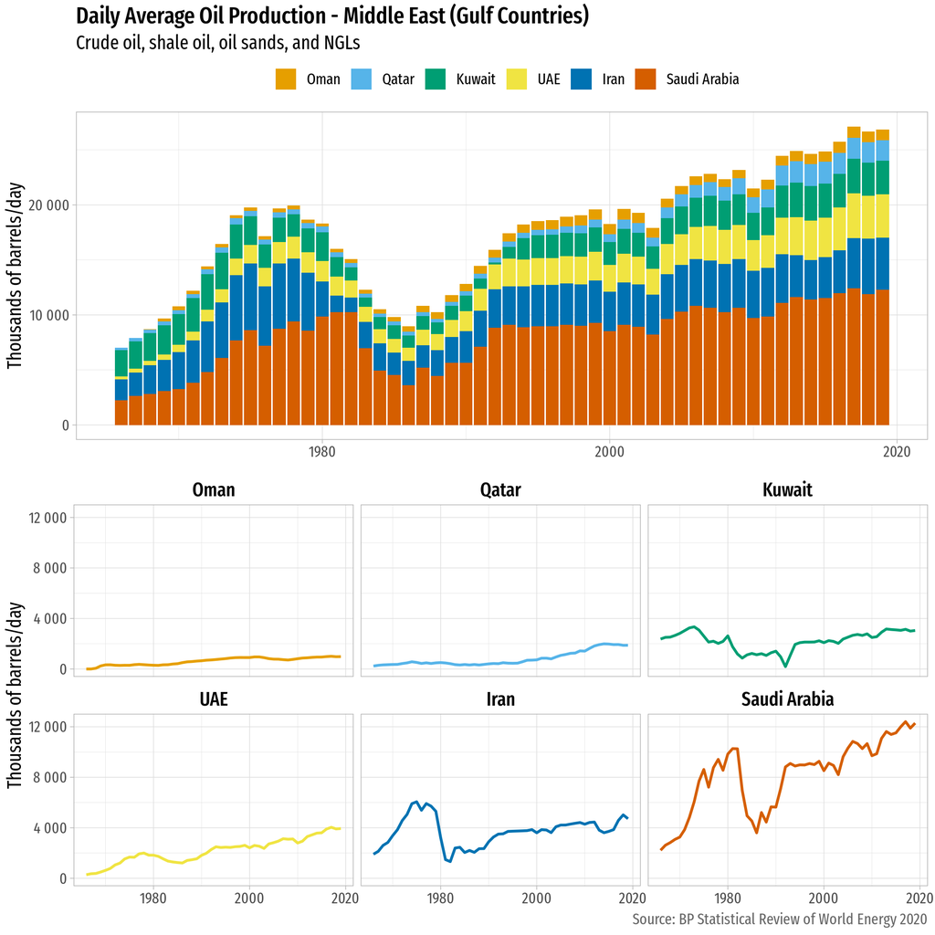

```r
library(ggplot2)
library(gridExtra)

# Read in data file to data frame, get latest year
df <- read.csv('data/oildata.csv', sep=';',
               colClasses=c("Date","numeric","factor"))

# Re-order so largest values sink to bottom
df_ord <- df[df$Date == max(df$Date),]
df$Country <- factor(df$Country,
                     levels=df_ord$Country[order(df_ord$Value, decreasing=FALSE)])

# Okabe Ito colour map
okabe <- c("#E69F00", "#56B4E9", "#009E73", "#F0E442", "#0072B2", "#D55E00", "#CC79A7")

# Number format function
numfmt <- function(x) format(x, big.mark=" ", decimal.mark=".", scientific=FALSE)

# Plot data
par(mfrow=c(1,1))

# First chart - stacked bar
p1 <- ggplot(df) +
    # Data series
    geom_bar(aes(fill=Country, x=Date, y=Value), position="stack", stat="identity") +
    # Axis scales and colour scales
    scale_y_continuous(label=numfmt) +
    scale_fill_discrete(type=okabe,
                        guide=guide_legend(nrow=1)) +
    # Plot labels
    labs(title="Daily Average Oil Production - Middle East (Gulf Countries)",
         x=NULL, y="Thousands of barrels/day",
         subtitle="Crude oil, shale oil, oil sands, and NGLs",
         fill=NULL) +
    # Themeing & fonts
    theme_light() +
    theme(legend.position="top",
          text=element_text(size=15, family="Fira Sans Extra Condensed"),
          plot.title=element_text(family="Fira Sans Extra Condensed Medium"),
          plot.caption=element_text(color="#666666"))

# Second chart - faceted lines
p2 <- ggplot(df) +
    # Data series
    geom_line(aes(x=Date,y=Value,color=Country), size=1) +
    # Facet the series
    facet_wrap(vars(Country),ncol=3) +
    # Axis scales and colour scales
    scale_y_continuous(label=numfmt) +
    scale_color_discrete(type=okabe) +
    # Plot labels
    labs(title=NULL,
         x=NULL, y="Thousands of barrels/day",
         subtitle=NULL,
         caption="Source: BP Statistical Review of World Energy 2020") +
    # Themeing & fonts
    theme_light() +
    theme(legend.position="hidden", strip.background=element_blank(),
          text=element_text(size=15, family="Fira Sans Extra Condensed"),
          plot.title=element_text(family="Fira Sans Extra Condensed Medium"),
          plot.caption=element_text(color="#666666"),
          strip.text=element_text(size=15, color="black",
                                  family="Fira Sans Extra Condensed Medium"))

# Display the 2 plots
grid.arrange(p1, p2, nrow=2)
```

## Heatmap: `stat_bin2d()`

Not a proper analysis, but enough to get an example heatmap. Some programs of course don’t respect the IANA service/ports registry mappings, but the common ports are probably accurate.

- Heatmap using `stat_bin2d()`
- Both factors re-sorted in decreasing order (roughly: bottom-left highest, top-right lowest)
- Legend moved to bottom (data first, then legend)
- Custom fonts
- Continuous colour scale - using `log2`

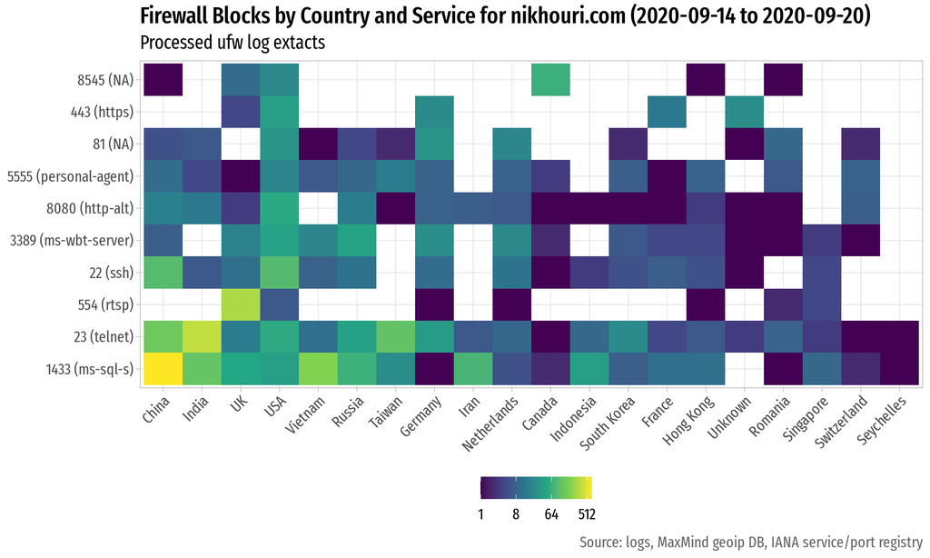

```r
library(ggplot2)

# Read in data file to data frame
df <- read.csv('data/ufwdata.csv', sep=';',
               colClasses=c("POSIXct","character","character"))

# Filter for top 10 countries, and then top 10 services within them
top <- df[df$country %in% names(tail(sort(table(df$country)),n=20)),]
top <- top[top$service %in% names(tail(sort(table(top$service)),n=10)),]

# Re-order factors based on overall counts
top$country <- factor(top$country,
                      levels=names(sort(table(top$country),decreasing=TRUE)))
top$service <- factor(top$service,
                      levels=names(sort(table(top$service),decreasing=TRUE)))

# Plot heatmap
ggplot(top) +
    # Data set
    stat_bin2d(aes(x=country, y=service, fill=after_stat(count))) +
    # Axis scales and colour scales
    scale_fill_continuous(type="viridis", trans="log2") +
    # Plot Labels
    labs(title="Firewall Blocks by Country and Service for nikhouri.com (2020-09-14 to 2020-09-20)",
         subtitle="Processed ufw log extacts",
         caption="Source: logs, MaxMind geoip DB, IANA service/port registry",
         x=NULL ,y=NULL, fill=NULL) +
    # Themeing & Fonts
    theme_light() +
    theme(legend.position="bottom",
          axis.text.x=element_text(angle=45, hjust=1),
          text=element_text(size=15, family="Fira Sans Extra Condensed"),
          plot.title=element_text(family="Fira Sans Extra Condensed Medium"),
          plot.caption=element_text(color="#666666"))
```

## Map: `geom_map()`

Note you’ll probably need to do some remapping of country names to get them to work with (as in this case, using MaxMind Geolocation output from IP addresses)

- Map plot with countries highlighted
- Legend moved to bottom (data first, then legend)
- Custom fonts
- Continuous colour scale - using `log2`

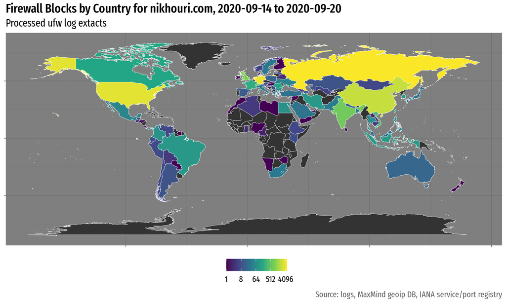

```r
library(ggplot2)
suppressPackageStartupMessages(library(rworldmap)) # Noisy startup

# Read in data file to data frame
df <- read.csv('data/ufwdata.csv', sep=';',
               colClasses=c("POSIXct","character","character"))

# Turn it into a count of hits from each country
dfc <- as.data.frame(table(df$country))
colnames(dfc) <- c("Country","Count")

# Plot map
world <- map_data("world")
ggplot() +
    # Map outline
    geom_map(dat=world, map=world, aes(map_id=region), fill="#333333",
             color="white",size=0.15) +
    # Country data
    geom_map(data=dfc, map=world, aes(map_id=Country,fill=Count),
             color="white",size=0.15) +
    # Axis scales and colour scales
    expand_limits(x=world$long,y=world$lat) +
    scale_x_continuous(label=NULL) +
    scale_y_continuous(label=NULL) +
    scale_fill_continuous(type="viridis", trans='log2') +
    # Plot Labels
    labs(title="Firewall Blocks by Country for nikhouri.com, 2020-09-14 to 2020-09-20",
         subtitle="Processed ufw log extacts",
         caption="Source: logs, MaxMind geoip DB, IANA service/port registry",
         x=NULL ,y=NULL, fill=NULL) +
    # Themeing & fonts
    theme_dark() +
    theme(legend.position="bottom",
          text=element_text(size=15, family="Fira Sans Extra Condensed"),
          plot.title=element_text(family="Fira Sans Extra Condensed Medium"),
          plot.caption=element_text(color="#666666"))
```